# Multi-Channel Website Performance Forecasting and Engagement Analysis

## Introduction

This project applies time series analysis to website performance data, exploring hourly user traffic, sessions, engagement, and conversions across channels such as Direct, Organic Search, Organic Social, and Referrals. The dataset was obtained from the [Statso Website Performance Case Study](https://statso.io/website-performance-case-study/).

By uncovering patterns, forecasting trends, and detecting anomalies with techniques such as ARIMA and seasonal decomposition, the analysis provides actionable insights to optimize user experience, channel effectiveness, and strategic decision-making.

## Primary Objective:

- Build and validate time-series forecasting models to predict sessions
- Analyze engagement patterns and trends over time
- Identify seasonal patterns and peak performance hours
- Compare performance across different marketing channels

```python
import sys
print("Python executable:", sys.executable)
print("Python path:", sys.path[0])
```

```
Python executable: C:\Users\DELL\miniconda3\envs\timeseries_env\python.exe
Python path: C:\Users\DELL\miniconda3\envs\timeseries_env\python310.zip
```

```python
# Test all imports
import pandas as pd
import numpy as np
import matplotlib as plt
import seaborn as sns
import scipy
import statsmodels

print(f"NumPy: {np.__version__}")
print(f"SciPy: {scipy.__version__}")
print(f"Statsmodels: {statsmodels.__version__}")

# Test your original problematic imports
from statsmodels.tsa.seasonal import seasonal_decompose
from statsmodels.tsa.stattools import adfuller
from statsmodels.graphics.tsaplots import plot_acf, plot_pacf
from statsmodels.tsa.arima.model import ARIMA
from sklearn.metrics import mean_squared_error, mean_absolute_error
from sklearn.preprocessing import StandardScaler

print("✅ All imports successful!")
```

```
NumPy: 1.26.4
SciPy: 1.15.2
Statsmodels: 0.14.5
✅ All imports successful!
```

```python
import matplotlib.pyplot as plt
import seaborn as sns

# Set style for plots
plt.style.use('seaborn-v0_8')
sns.set_palette("husl")
```

## Data Loading and Initial Inspection

```python
df = pd.read_csv(r"C:\Users\DELL\Desktop\DATASETS\Time series Dataset\website Performance dataset.csv")
```

```python
df.head()
```

|  | Session primary channel group (Default channel group) | Date + hour (YYYYMMDDHH) | Users | Sessions | Engaged sessions | Average engagement time per session | Engaged sessions per user | Events per session | Engagement rate | Event count |
| --- | --- | --- | --- | --- | --- | --- | --- | --- | --- | --- |
| 0 | Direct | 2024041623 | 237 | 300 | 144 | 47.526667 | 0.607595 | 4.673333 | 0.480000 | 1402 |
| 1 | Organic Social | 2024041719 | 208 | 267 | 132 | 32.097378 | 0.634615 | 4.295880 | 0.494382 | 1147 |
| 2 | Direct | 2024041723 | 188 | 233 | 115 | 39.939914 | 0.611702 | 4.587983 | 0.493562 | 1069 |
| 3 | Organic Social | 2024041718 | 187 | 256 | 125 | 32.160156 | 0.668449 | 4.078125 | 0.488281 | 1044 |
| 4 | Organic Social | 2024041720 | 175 | 221 | 112 | 46.918552 | 0.640000 | 4.529412 | 0.506787 | 1001 |

```python
# Display basic information about the dataset

print("Dataset Shape:", df.shape)
print("\nColumn Names:")
print(df.columns.tolist())
print("\nData Types:")
print(df.dtypes)
print("\nMissing Values:")
print(df.isnull().sum())
```

```
Dataset Shape: (3182, 10)

Column Names:
['Session primary channel group (Default channel group)', 'Date + hour (YYYYMMDDHH)', 'Users', 'Sessions', 'Engaged sessions', 'Average engagement time per session', 'Engaged sessions per user', 'Events per session', 'Engagement rate', 'Event count']

Data Types:
Session primary channel group (Default channel group)     object
Date + hour (YYYYMMDDHH)                                   int64
Users                                                      int64
Sessions                                                   int64
Engaged sessions                                           int64
Average engagement time per session                      float64
Engaged sessions per user                                float64
Events per session                                       float64
Engagement rate                                          float64
Event count                                                int64
dtype: object

Missing Values:
Session primary channel group (Default channel group)    0
Date + hour (YYYYMMDDHH)                                 0
Users                                                    0
Sessions                                                 0
Engaged sessions                                         0
Average engagement time per session                      0
Engaged sessions per user                                0
Events per session                                       0
Engagement rate                                          0
Event count                                              0
dtype: int64
```

## Data Cleaning and Transformation

```python
# Rename column:

df = df.rename(columns={"Session primary channel group (Default channel group)": "Session primary channel group"})


df = df.rename(columns={"Date + hour (YYYYMMDDHH)": "Datetime"})
```

```python
df.head()
```

|  | Session primary channel group | Datetime | Users | Sessions | Engaged sessions | Average engagement time per session | Engaged sessions per user | Events per session | Engagement rate | Event count |
| --- | --- | --- | --- | --- | --- | --- | --- | --- | --- | --- |
| 0 | Direct | 2024041623 | 237 | 300 | 144 | 47.526667 | 0.607595 | 4.673333 | 0.480000 | 1402 |
| 1 | Organic Social | 2024041719 | 208 | 267 | 132 | 32.097378 | 0.634615 | 4.295880 | 0.494382 | 1147 |
| 2 | Direct | 2024041723 | 188 | 233 | 115 | 39.939914 | 0.611702 | 4.587983 | 0.493562 | 1069 |
| 3 | Organic Social | 2024041718 | 187 | 256 | 125 | 32.160156 | 0.668449 | 4.078125 | 0.488281 | 1044 |
| 4 | Organic Social | 2024041720 | 175 | 221 | 112 | 46.918552 | 0.640000 | 4.529412 | 0.506787 | 1001 |

```python
# Convert the date column to proper datetime format

df['Datetime'] = df['Datetime'].astype(str)
df['datetime'] = pd.to_datetime(df['Datetime'], format='%Y%m%d%H')

# Set datetime as index
df.set_index('datetime', inplace=True)
```

```python
df.head(2)
```

| datetime | Session primary channel group | Datetime | Users | Sessions | Engaged sessions | Average engagement time per session | Engaged sessions per user | Events per session | Engagement rate | Event count |
| --- | --- | --- | --- | --- | --- | --- | --- | --- | --- | --- |
| 2024-04-16 23:00:00 | Direct | 2024041623 | 237 | 300 | 144 | 47.526667 | 0.607595 | 4.673333 | 0.480000 | 1402 |
| 2024-04-17 19:00:00 | Organic Social | 2024041719 | 208 | 267 | 132 | 32.097378 | 0.634615 | 4.295880 | 0.494382 | 1147 |

```python
# Check for duplicates

print("Duplicate rows:", df.duplicated().sum())
```

```
Duplicate rows: 0
```

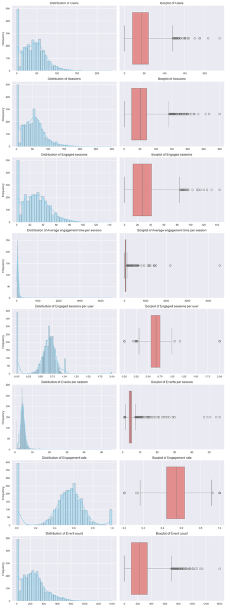

```python
# Check for outliers

# Select numerical columns
num_cols = [
    "Users", "Sessions", "Engaged sessions",
    "Average engagement time per session",
    "Engaged sessions per user", "Events per session",
    "Engagement rate", "Event count"
]

# Set up the figure grid
fig, axes = plt.subplots(len(num_cols), 2, figsize=(12, 4*len(num_cols)))

for i, col in enumerate(num_cols):
    # Distribution (histogram + KDE)
    sns.histplot(data=df, x=col, kde=True, ax=axes[i,0], color="skyblue")
    axes[i,0].set_title(f"Distribution of {col}")
    axes[i,0].set_xlabel("")
    axes[i,0].set_ylabel("Frequency")

    # Boxplot
    sns.boxplot(data=df, x=col, ax=axes[i,1], color="lightcoral")
    axes[i,1].set_title(f"Boxplot of {col}")
    axes[i,1].set_xlabel("")

plt.tight_layout()
plt.show()
```

```python
# Create additional time-based features

df['hour'] = df.index.hour
df['day_of_week'] = df.index.dayofweek
df['day_of_month'] = df.index.day
df['month'] = df.index.month
df['week_of_year'] = df.index.isocalendar().week
```

```python
# Display cleaned data info
print("\nCleaned Dataset Info:")
print(df.info())
print()
print("\nSample of cleaned data:")

df.head()
```

```
Cleaned Dataset Info:
<class 'pandas.core.frame.DataFrame'>
DatetimeIndex: 3182 entries, 2024-04-16 23:00:00 to 2024-05-03 07:00:00
Data columns (total 15 columns):
 #   Column                               Non-Null Count  Dtype
---  ------                               --------------  -----
 0   Session primary channel group        3182 non-null   object
 1   Datetime                             3182 non-null   object
 2   Users                                3182 non-null   int64
 3   Sessions                             3182 non-null   int64
 4   Engaged sessions                     3182 non-null   int64
 5   Average engagement time per session  3182 non-null   float64
 6   Engaged sessions per user            3182 non-null   float64
 7   Events per session                   3182 non-null   float64
 8   Engagement rate                      3182 non-null   float64
 9   Event count                          3182 non-null   int64
 10  hour                                 3182 non-null   int32
 11  day_of_week                          3182 non-null   int32
 12  day_of_month                         3182 non-null   int32
 13  month                                3182 non-null   int32
 14  week_of_year                         3182 non-null   UInt32
dtypes: UInt32(1), float64(4), int32(4), int64(4), object(2)
memory usage: 338.7+ KB
None


Sample of cleaned data:
```

| datetime | Session primary channel group | Datetime | Users | Sessions | Engaged sessions | Average engagement time per session | Engaged sessions per user | Events per session | Engagement rate | Event count | hour | day_of_week | day_of_month | month | week_of_year |
| --- | --- | --- | --- | --- | --- | --- | --- | --- | --- | --- | --- | --- | --- | --- | --- |
| 2024-04-16 23:00:00 | Direct | 2024041623 | 237 | 300 | 144 | 47.526667 | 0.607595 | 4.673333 | 0.480000 | 1402 | 23 | 1 | 16 | 4 | 16 |
| 2024-04-17 19:00:00 | Organic Social | 2024041719 | 208 | 267 | 132 | 32.097378 | 0.634615 | 4.295880 | 0.494382 | 1147 | 19 | 2 | 17 | 4 | 16 |
| 2024-04-17 23:00:00 | Direct | 2024041723 | 188 | 233 | 115 | 39.939914 | 0.611702 | 4.587983 | 0.493562 | 1069 | 23 | 2 | 17 | 4 | 16 |
| 2024-04-17 18:00:00 | Organic Social | 2024041718 | 187 | 256 | 125 | 32.160156 | 0.668449 | 4.078125 | 0.488281 | 1044 | 18 | 2 | 17 | 4 | 16 |
| 2024-04-17 20:00:00 | Organic Social | 2024041720 | 175 | 221 | 112 | 46.918552 | 0.640000 | 4.529412 | 0.506787 | 1001 | 20 | 2 | 17 | 4 | 16 |

## Exploratory Data Analysis

```python
# Summary statistics

print("Summary Statistics:")
print(df.describe())
```

```
Summary Statistics:
             Users     Sessions  Engaged sessions  \
count  3182.000000  3182.000000       3182.000000
mean     41.935889    51.192646         28.325581
std      29.582258    36.919962         20.650569
min       0.000000     1.000000          0.000000
25%      20.000000    24.000000         13.000000
50%      42.000000    51.000000         27.000000
75%      60.000000    71.000000         41.000000
max     237.000000   300.000000        144.000000

       Average engagement time per session  Engaged sessions per user  \
count                          3182.000000                3182.000000
mean                             66.644581                   0.606450
std                             127.200659                   0.264023
min                               0.000000                   0.000000
25%                              32.103034                   0.561404
50%                              49.020202                   0.666667
75%                              71.487069                   0.750000
max                            4525.000000                   2.000000

       Events per session  Engagement rate  Event count         hour  \
count         3182.000000      3182.000000  3182.000000  3182.000000
mean             4.675969         0.503396   242.272470    11.807040
std              2.795228         0.228206   184.440313     6.886686
min              1.000000         0.000000     1.000000     0.000000
25%              3.750000         0.442902   103.000000     6.000000
50%              4.410256         0.545455   226.000000    12.000000
75%              5.217690         0.633333   339.000000    18.000000
max             56.000000         1.000000  1402.000000    23.000000

       day_of_week  day_of_month        month  week_of_year
count  3182.000000   3182.000000  3182.000000        3182.0
mean      2.995286     16.318353     4.108108     16.223759
std       1.990620      8.411839     0.310566      1.202361
min       0.000000      1.000000     4.000000          14.0
25%       1.000000     10.000000     4.000000          15.0
50%       3.000000     17.000000     4.000000          16.0
75%       5.000000     24.000000     4.000000          17.0
max       6.000000     30.000000     5.000000          18.0
```

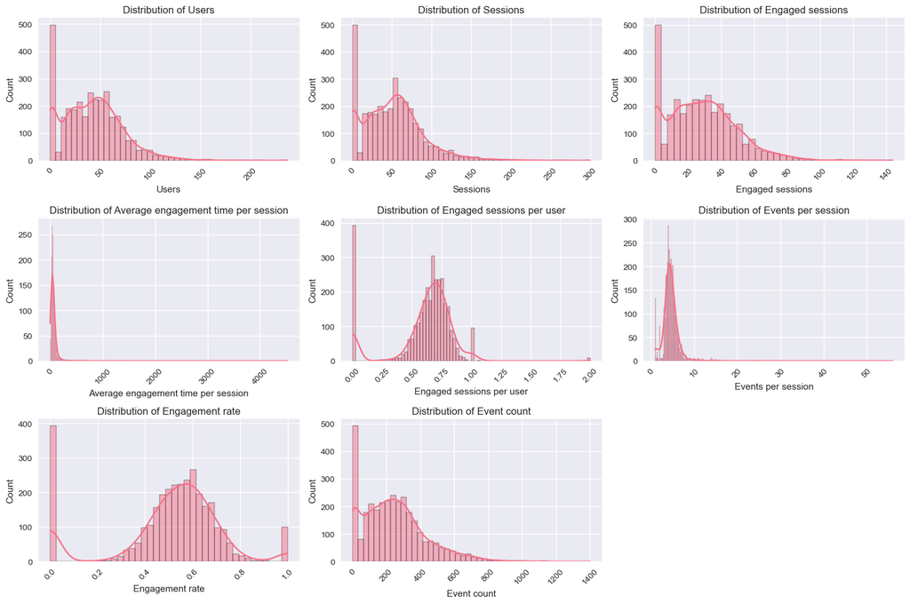

```python
# Plot distribution of numerical variables
numerical_cols = ['Users', 'Sessions', 'Engaged sessions', 'Average engagement time per session',
                 'Engaged sessions per user', 'Events per session', 'Engagement rate', 'Event count']

plt.figure(figsize=(15, 10))
for i, col in enumerate(numerical_cols, 1):
    plt.subplot(3, 3, i)
    sns.histplot(df[col], kde=True)
    plt.title(f'Distribution of {col}')
    plt.xticks(rotation=45)
plt.tight_layout()
plt.show()
```

- Most activity-based metrics (Users, Sessions, Engaged Sessions, Event Count, Engagement Time, and Events per Session) are right-skewed, meaning most values are low with a few very high outliers.
- Engaged Sessions per User is roughly normal, peaking around 0.6–0.7, showing consistent user contribution to engagement.
- Engagement Rate centers around 0.5–0.6 in a bell-shaped pattern, indicating moderate typical engagement.

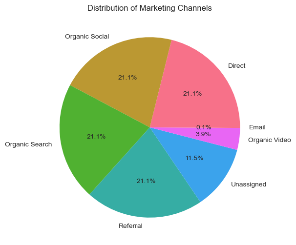

```python
# Channel analysis
plt.figure(figsize=(12, 6))
channel_counts = df['Session primary channel group'].value_counts()
plt.pie(channel_counts.values, labels=channel_counts.index, autopct='%1.1f%%')
plt.title('Distribution of Marketing Channels')
plt.show()
```

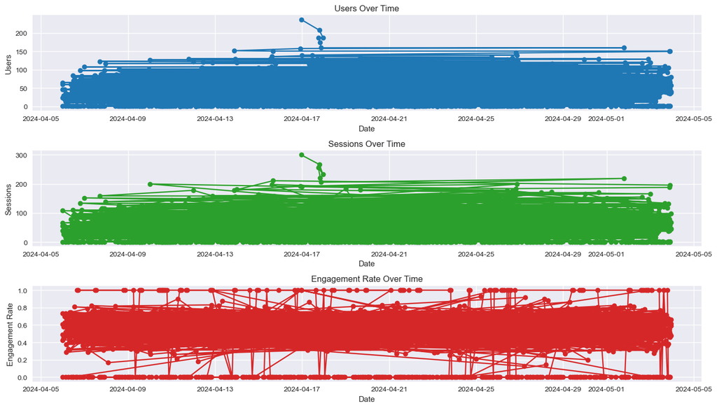

```python
# Visualization of time seres key metrics:


import matplotlib.pyplot as plt

# Ensure datetime index is in datetime format
df.index = pd.to_datetime(df.index)

plt.figure(figsize=(14, 8))

# Plot Users over time
plt.subplot(3, 1, 1)
plt.plot(df.index, df["Users"], marker="o", linestyle="-", color="tab:blue")
plt.title("Users Over Time")
plt.xlabel("Date")
plt.ylabel("Users")
plt.grid(True)

# Plot Sessions over time
plt.subplot(3, 1, 2)
plt.plot(df.index, df["Sessions"], marker="o", linestyle="-", color="tab:green")
plt.title("Sessions Over Time")
plt.xlabel("Date")
plt.ylabel("Sessions")
plt.grid(True)

# Plot Engagement Rate over time
plt.subplot(3, 1, 3)
plt.plot(df.index, df["Engagement rate"], marker="o", linestyle="-", color="tab:red")
plt.title("Engagement Rate Over Time")
plt.xlabel("Date")
plt.ylabel("Engagement Rate")
plt.grid(True)

plt.tight_layout()
plt.show()
```

– User activity fluctuates across the period, with noticeable spikes around mid-April, suggesting traffic surges possibly due to campaigns or external events.

– Sessions follow a similar trend to users, indicating that session counts are strongly tied to user visits, with peaks aligning with user spikes.

## Time Series Decomposition

```python
from statsmodels.tsa.seasonal import seasonal_decompose
```

```
📊 Daily data: 28 days available

🔍 Analyzing Users...
```

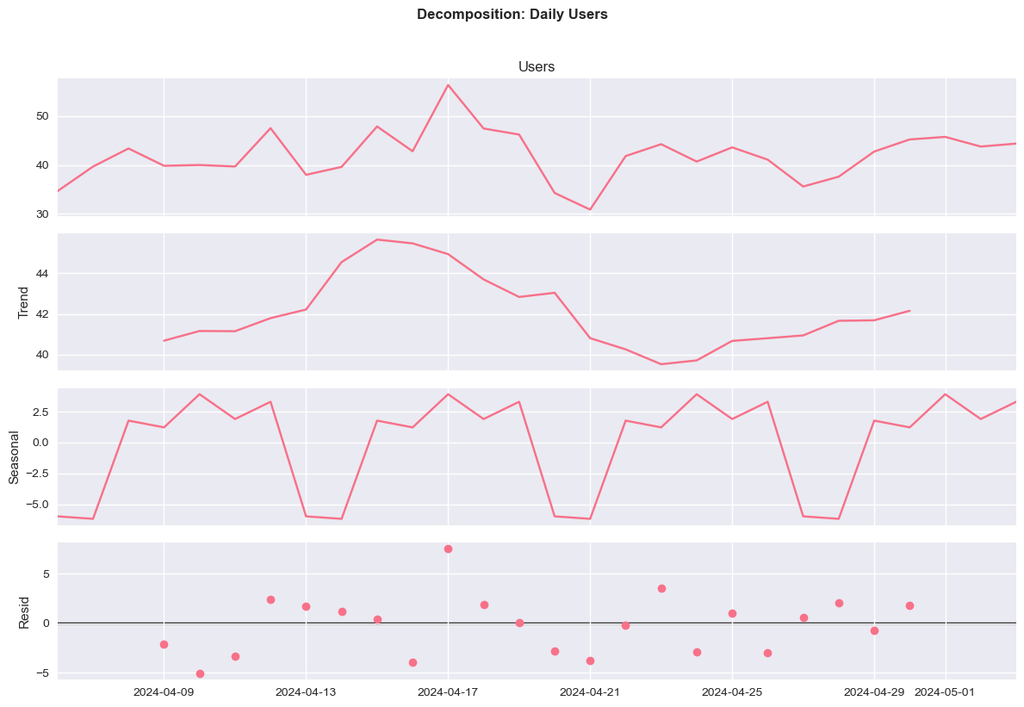

```
🔍 Analyzing Engagement rate...
```

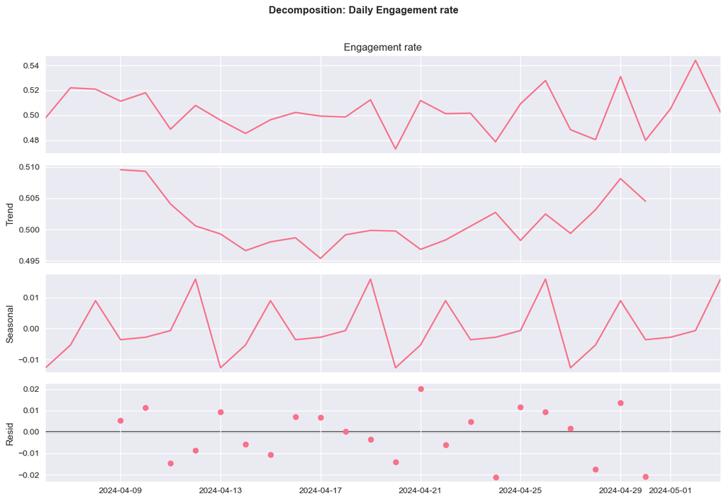

```
✅ Successful decompositions: 2/2
```

```python
# Time Series Decomposition
def clean_decomposition(series, title, period=7):
    """Clean decomposition with error handling"""
    try:
        result = seasonal_decompose(series.dropna(), model='additive', period=min(period, len(series)//2))
        fig = result.plot()
        fig.suptitle(f'Decomposition: {title}', y=1.02, fontweight='bold')
        fig.set_size_inches(12, 8)
        plt.tight_layout()
        plt.show()
        return True
    except Exception as e:
        print(f"⚠️  Could not decompose {title}: {str(e)[:100]}...")
        return False

# Get numerical data
numerical_cols = df.select_dtypes(include=[np.number]).columns.tolist()
daily_df = df[numerical_cols].resample('D').mean()

print(f"📊 Daily data: {daily_df.shape[0]} days available")

# Decompose key metrics
metrics_to_decompose = ['Users', 'Engagement rate']
successful_decompositions = 0

for metric in metrics_to_decompose:
    if metric in daily_df.columns:
        print(f"\n🔍 Analyzing {metric}...")
        if clean_decomposition(daily_df[metric], f'Daily {metric}'):
            successful_decompositions += 1

# Fallback to hourly if daily decomposition fails
if successful_decompositions == 0:
    print("\n🔄 Trying hourly decomposition as fallback...")
    for metric in metrics_to_decompose:
        if metric in df.columns:
            clean_decomposition(df[metric], f'Hourly {metric}', period=24)

# Quick summary
print(f"\n✅ Successful decompositions: {successful_decompositions}/{len(metrics_to_decompose)}")
```

- The data shows a stable underlying trend around 40-45 daily users with clear weekly seasonal patterns indicating consistent day-of-week effects on user behavior.
- The small, random residuals around zero suggest the decomposition effectively captures the main patterns, making this suitable for reliable forecasting.
- The engagement rate shows a notable declining trend from ~0.51 to ~0.498 in mid-April, followed by a recovery back toward 0.51 by early May.

## Correlation Analysis

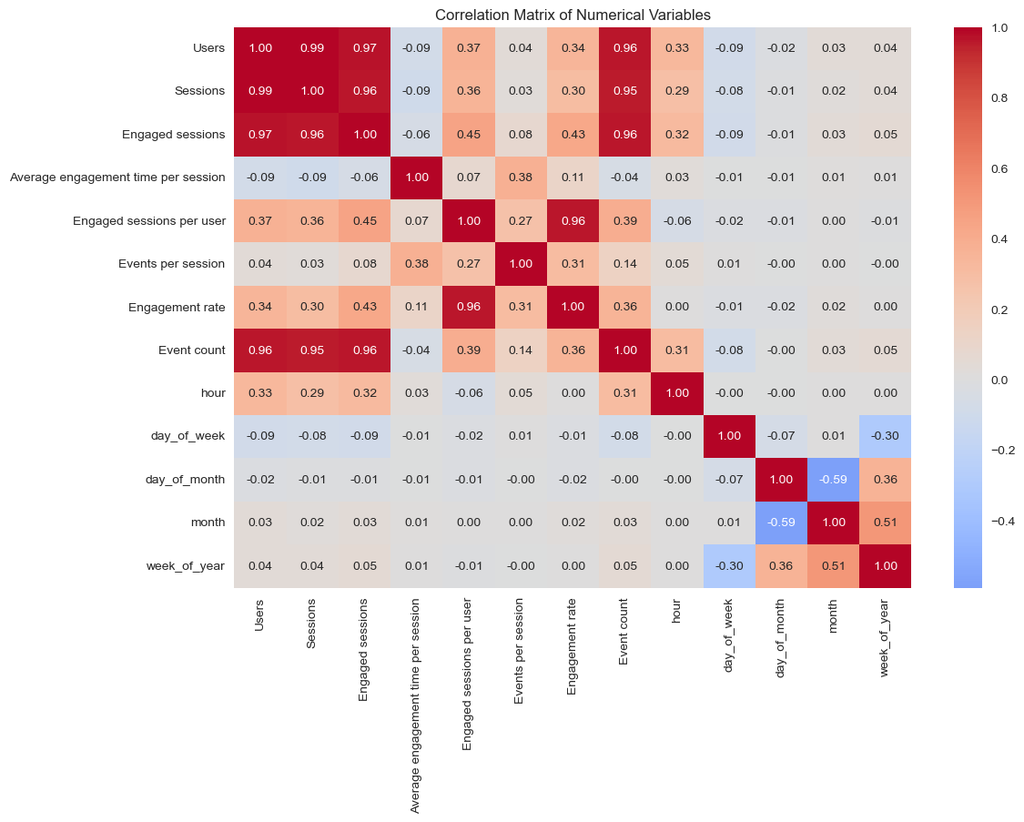

```python
# Correlation matrix

correlation_matrix = df[numerical_cols].corr()

plt.figure(figsize=(12, 8))
sns.heatmap(correlation_matrix, annot=True, cmap='coolwarm', center=0, fmt='.2f')
plt.title('Correlation Matrix of Numerical Variables')
plt.show()
```

- Users, Sessions, and Engaged sessions show very high correlations (0.95-0.99), indicating these core traffic metrics move together, while engagement quality metrics like engagement rate and engaged sessions per user also correlate strongly (0.96).

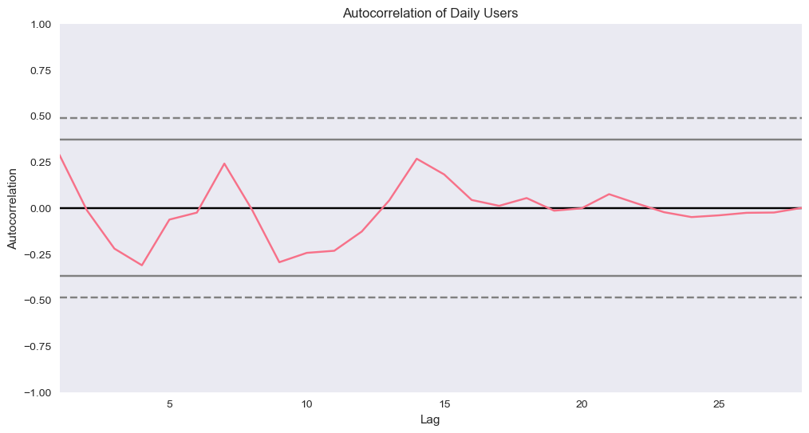

```python
# Lag analysis for autocorrelation
from pandas.plotting import autocorrelation_plot

plt.figure(figsize=(12, 6))
autocorrelation_plot(daily_df['Users'].dropna())
plt.title('Autocorrelation of Daily Users')
plt.show()
```

## Channel-wise Analysis

```
Average Metrics by Channel:
                               Users  Sessions  Engaged sessions  \
Session primary channel group
Direct                         44.71     55.36             25.66
Email                           0.67      1.00              0.33
Organic Search                 42.24     49.66             28.91
Organic Social                 70.79     90.22             48.66
Organic Video                   0.98      1.13              0.87
Referral                       39.84     46.12             30.73
Unassigned                      1.48      1.53              0.01

                               Average engagement time per session  \
Session primary channel group
Direct                                                       45.53
Email                                                        72.67
Organic Search                                               47.01
Organic Social                                               53.49
Organic Video                                               180.36
Referral                                                     92.66
Unassigned                                                   78.96

                               Engaged sessions per user  Events per session  \
Session primary channel group
Direct                                              0.57                4.15
Email                                               0.33                3.33
Organic Search                                      0.69                4.07
Organic Social                                      0.69                4.91
Organic Video                                       0.83                7.52
Referral                                            0.77                5.67
Unassigned                                          0.01                3.53

                               Engagement rate  Event count   hour  \
Session primary channel group
Direct                                    0.46       232.62  11.50
Email                                     0.33         3.33   8.33
Organic Search                            0.58       203.81  11.50
Organic Social                            0.54       441.42  11.50
Organic Video                             0.76         8.57  14.09
Referral                                  0.66       264.87  11.50
Unassigned                                0.01         5.28  13.31

                               day_of_week  day_of_month  month  week_of_year
Session primary channel group
Direct                                3.00         16.29   4.11         16.21
Email                                 4.00         19.00   4.00          16.0
Organic Search                        3.00         16.29   4.11         16.21
Organic Social                        3.00         16.29   4.11         16.21
Organic Video                         2.96         15.61   4.17         16.38
Referral                              3.00         16.29   4.11         16.21
Unassigned                            2.96         16.78   4.10         16.24
```

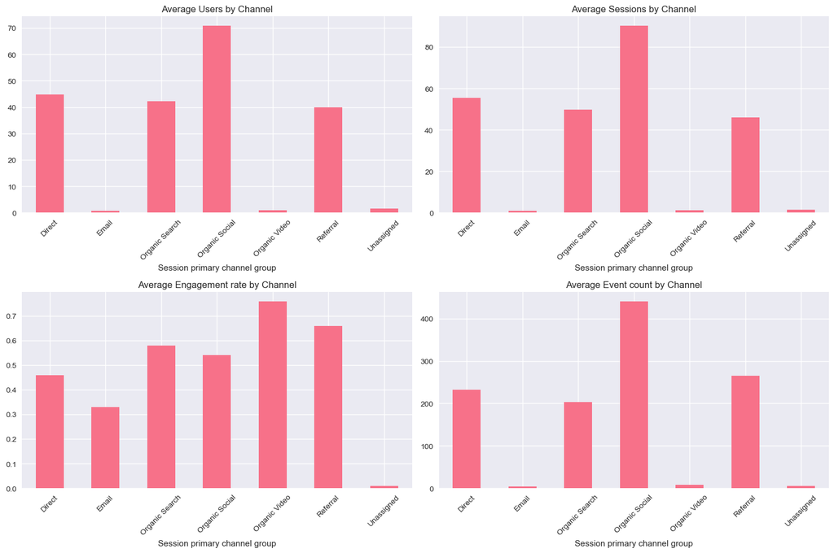

```python
# Compare metrics across channels
channel_col = df.columns[0]  # Assuming first column is the channel
channel_metrics = df.groupby(channel_col)[numerical_cols].mean().round(2)

print("Average Metrics by Channel:")
print(channel_metrics)

# Plot channel performance - select only numerical columns that exist
plot_columns = [col for col in ['Users', 'Sessions', 'Engagement rate', 'Event count'] if col in numerical_cols]

if len(plot_columns) > 0:
    fig, axes = plt.subplots(2, 2, figsize=(15, 10))
    axes = axes.flatten()

    for i, col in enumerate(plot_columns):
        if i < 4:  # Ensure we don't exceed subplot count
            channel_metrics[col].plot(kind='bar', ax=axes[i], title=f'Average {col} by Channel')
            plt.sca(axes[i])
            plt.xticks(rotation=45)

    # Hide empty subplots if we have less than 4 columns
    for i in range(len(plot_columns), 4):
        axes[i].set_visible(False)

    plt.tight_layout()
    plt.show()
else:
    print("No numerical columns available for channel analysis")
```

## Time-based Pattern Analysis

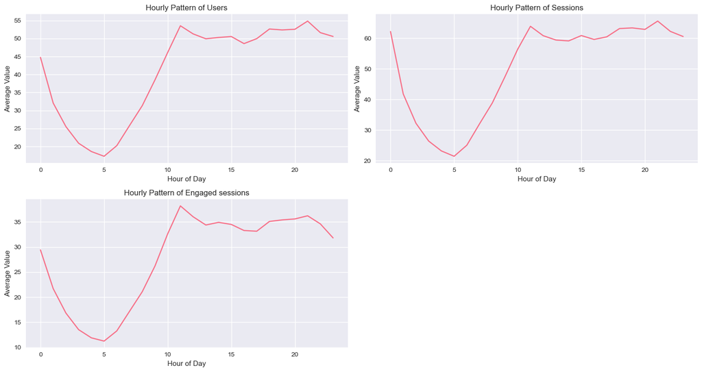

```python
# Hourly patterns
hourly_patterns = df.groupby('hour')[numerical_cols].mean()

# Plot only if we have numerical columns
if len(numerical_cols) > 0:
    plt.figure(figsize=(15, 8))
    for i, col in enumerate(numerical_cols[:3], 1):  # Plot first 3 numerical columns
        plt.subplot(2, 2, i)
        hourly_patterns[col].plot()
        plt.title(f'Hourly Pattern of {col}')
        plt.xlabel('Hour of Day')
        plt.ylabel('Average Value')
        plt.grid(True)
    plt.tight_layout()
    plt.show()
```

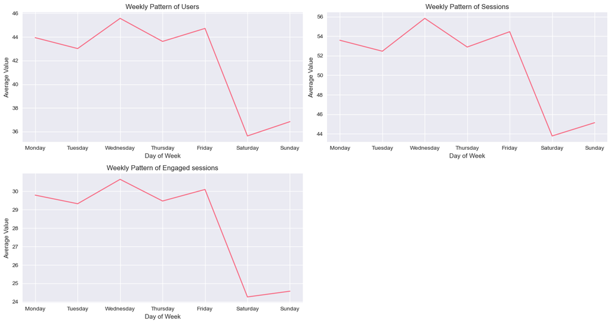

```python
# Weekly patterns
weekday_names = ['Monday', 'Tuesday', 'Wednesday', 'Thursday', 'Friday', 'Saturday', 'Sunday']
weekly_patterns = df.groupby('day_of_week')[numerical_cols].mean()
weekly_patterns.index = weekday_names

if len(numerical_cols) > 0:
    plt.figure(figsize=(15, 8))
    for i, col in enumerate(numerical_cols[:3], 1):  # Plot first 3 numerical columns
        plt.subplot(2, 2, i)
        weekly_patterns[col].plot()
        plt.title(f'Weekly Pattern of {col}')
        plt.xlabel('Day of Week')
        plt.ylabel('Average Value')
        plt.grid(True)
    plt.tight_layout()
    plt.show()
```

## Stationarity Check

```python
from statsmodels.tsa.stattools import adfuller

# Check stationarity for key metrics
def check_stationarity(series, title):
    result = adfuller(series.dropna())
    print(f'ADF Statistic for {title}: {result[0]}')
    print(f'p-value: {result[1]}')
    print('Critical Values:')
    for key, value in result[4].items():
        print(f'   {key}: {value}')
    print('\n')

check_stationarity(daily_df['Users'], 'Daily Users')
check_stationarity(daily_df['Engagement rate'], 'Daily Engagement Rate')
```

```
ADF Statistic for Daily Users: -3.8558831568284937
p-value: 0.0023846102721356275
Critical Values:
   1%: -3.6996079738860943
   5%: -2.9764303469999494
   10%: -2.627601001371742


ADF Statistic for Daily Engagement Rate: -4.58863530612097
p-value: 0.00013554525931200805
Critical Values:
   1%: -3.7112123008648155
   5%: -2.981246804733728
   10%: -2.6300945562130176
```

Stationarity Analysis Results Daily Users:

ADF Statistic: -3.856 (more negative than all critical values)

p-value: 0.0024 (< 0.05)

Conclusion: Stationary (reject null hypothesis of non-stationarity)

Daily Engagement Rate:

ADF Statistic: -4.589 (more negative than all critical values)

p-value: 0.00014 (< 0.05)

Conclusion: Stationary (reject null hypothesis of non-stationarity)

Since both series are stationary, we don't need differencing for our ARIMA models.

## Forecasting Preparation

```python
from sklearn.model_selection import train_test_split
from sklearn.preprocessing import StandardScaler
from sklearn.metrics import mean_absolute_error, mean_squared_error

# Prepare data for forecasting
forecast_df = daily_df[['Users', 'Sessions', 'Engagement rate']].copy()

# Create lag features for time series forecasting
for lag in range(1, 8):  # 7 days of lag
    forecast_df[f'Users_lag_{lag}'] = forecast_df['Users'].shift(lag)
    forecast_df[f'Engagement_lag_{lag}'] = forecast_df['Engagement rate'].shift(lag)

# Drop rows with NaN values after creating lags
forecast_df = forecast_df.dropna()

# Split into train and test sets
train_size = int(len(forecast_df) * 0.8)
train, test = forecast_df.iloc[:train_size], forecast_df.iloc[train_size:]

print(f"Train shape: {train.shape}")
print(f"Test shape: {test.shape}")
print(f"Train period: {train.index.min()} to {train.index.max()}")
print(f"Test period: {test.index.min()} to {test.index.max()}")
```

```
Train shape: (16, 17)
Test shape: (5, 17)
Train period: 2024-04-13 00:00:00 to 2024-04-28 00:00:00
Test period: 2024-04-29 00:00:00 to 2024-05-03 00:00:00
```

## Time Series Forecasting with ACF/PACF

```python
from statsmodels.tsa.arima.model import ARIMA
from statsmodels.tsa.statespace.sarimax import SARIMAX
from statsmodels.graphics.tsaplots import plot_acf, plot_pacf
```

```
Maximum allowed lags for ACF/PACF: 10
```

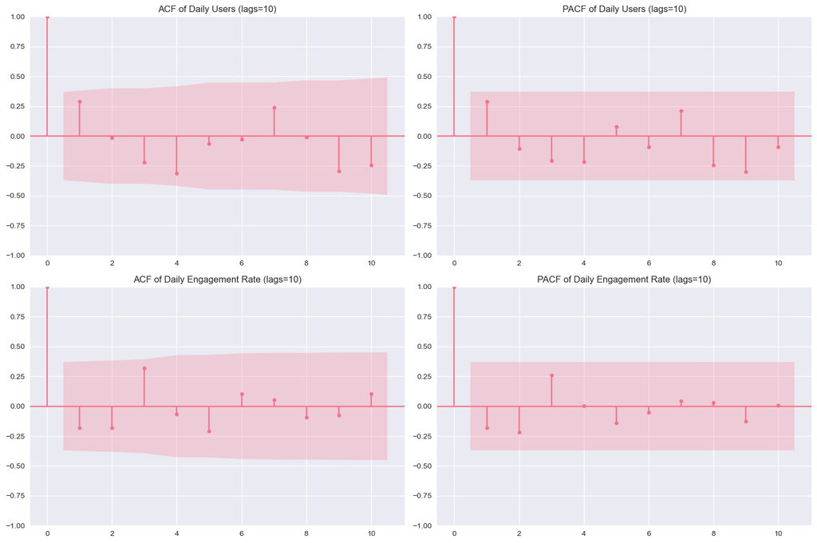

```python
# Calculate maximum allowed lags for our small dataset
max_lags = min(10, len(daily_df) // 2 - 1)  # Ensure lags < 50% of sample size
print(f"Maximum allowed lags for ACF/PACF: {max_lags}")

# Plot ACF and PACF with appropriate lags for small dataset
fig, axes = plt.subplots(2, 2, figsize=(15, 10))

plot_acf(daily_df['Users'].dropna(), ax=axes[0, 0], lags=max_lags)
axes[0, 0].set_title(f'ACF of Daily Users (lags={max_lags})')

plot_pacf(daily_df['Users'].dropna(), ax=axes[0, 1], lags=max_lags)
axes[0, 1].set_title(f'PACF of Daily Users (lags={max_lags})')

plot_acf(daily_df['Engagement rate'].dropna(), ax=axes[1, 0], lags=max_lags)
axes[1, 0].set_title(f'ACF of Daily Engagement Rate (lags={max_lags})')

plot_pacf(daily_df['Engagement rate'].dropna(), ax=axes[1, 1], lags=max_lags)
axes[1, 1].set_title(f'PACF of Daily Engagement Rate (lags={max_lags})')

plt.tight_layout()
plt.show()
```

```
With only 21 days of data, we'll use simple models:
ARIMA(1,0,1) model for Users fitted successfully
```

```
ARIMA(1,0,1) model for Engagement Rate fitted successfully
```

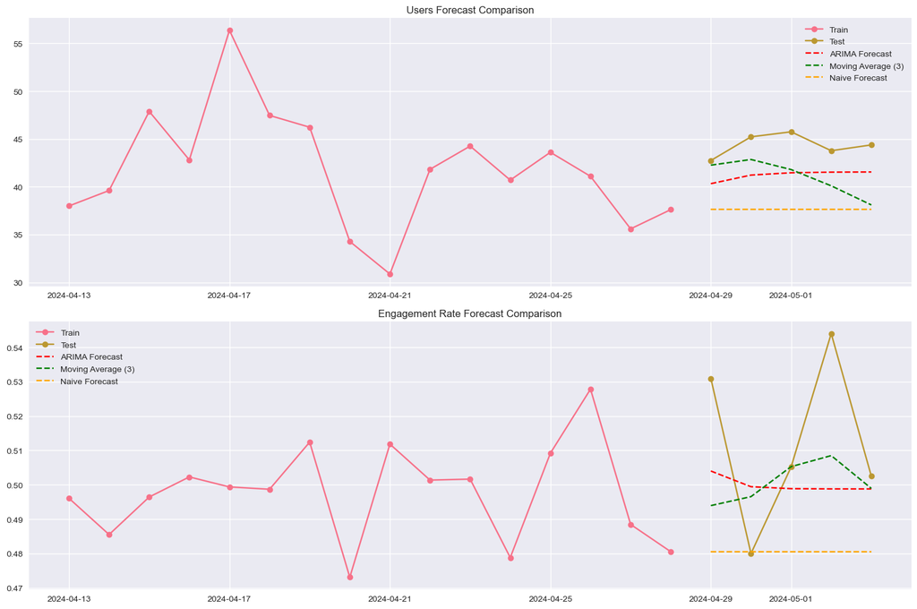

```python
# Since we have limited data, let's use simpler models
print("\nWith only 21 days of data, we'll use simple models:")

# Simple moving average as baseline
def simple_moving_average(series, window=3):
    return series.rolling(window=window).mean().iloc[-len(test):]

# Naive forecast (last value)
def naive_forecast(series):
    last_value = series.iloc[-1]
    return pd.Series([last_value] * len(test), index=test.index)

# ARIMA model for Users (simple order due to small dataset)
try:
    # For small datasets, use simple ARIMA orders
    model_users = ARIMA(train['Users'], order=(1,0,1))
    model_users_fit = model_users.fit()
    print("ARIMA(1,0,1) model for Users fitted successfully")

    # Forecast Users
    users_forecast = model_users_fit.forecast(steps=len(test))

except Exception as e:
    print(f"Error in ARIMA modeling for Users: {e}")
    print("Using naive forecast for Users")
    users_forecast = naive_forecast(train['Users'])

# ARIMA model for Engagement Rate
try:
    model_engagement = ARIMA(train['Engagement rate'], order=(1,0,1))
    model_engagement_fit = model_engagement.fit()
    print("ARIMA(1,0,1) model for Engagement Rate fitted successfully")

    # Forecast Engagement Rate
    engagement_forecast = model_engagement_fit.forecast(steps=len(test))

except Exception as e:
    print(f"Error in ARIMA modeling for Engagement Rate: {e}")
    print("Using naive forecast for Engagement Rate")
    engagement_forecast = naive_forecast(train['Engagement rate'])

# Also create simple baseline forecasts for comparison
users_ma = simple_moving_average(train['Users'])
engagement_ma = simple_moving_average(train['Engagement rate'])

# Plot forecasts
plt.figure(figsize=(15, 10))

plt.subplot(2, 1, 1)
plt.plot(train.index, train['Users'], label='Train', marker='o')
plt.plot(test.index, test['Users'], label='Test', marker='o')
plt.plot(test.index, users_forecast, label='ARIMA Forecast', color='red', linestyle='--', marker='x')
plt.plot(test.index, users_ma, label='Moving Average (3)', color='green', linestyle='--', marker='x')
plt.plot(test.index, naive_forecast(train['Users']), label='Naive Forecast', color='orange', linestyle='--', marker='x')
plt.title('Users Forecast Comparison')
plt.legend()
plt.grid(True)

plt.subplot(2, 1, 2)
plt.plot(train.index, train['Engagement rate'], label='Train', marker='o')
plt.plot(test.index, test['Engagement rate'], label='Test', marker='o')
plt.plot(test.index, engagement_forecast, label='ARIMA Forecast', color='red', linestyle='--', marker='x')
plt.plot(test.index, engagement_ma, label='Moving Average (3)', color='green', linestyle='--', marker='x')
plt.plot(test.index, naive_forecast(train['Engagement rate']), label='Naive Forecast', color='orange', linestyle='--', marker='x')
plt.title('Engagement Rate Forecast Comparison')
plt.legend()
plt.grid(True)

plt.tight_layout()
plt.show()
```

### Forecast Performance Comparison Across Multiple Models

**Chart Type:** Multi-model time series forecast comparison  
**Analysis Period:** 21 days of daily data (April 13 - May 3, 2024)  
**Models Tested:** ARIMA(1,0,1), 3-Day Moving Average, Naive (Last Value)

```python
# Calculate evaluation metrics for all models
def calculate_metrics(true, pred, metric_name):
    mae = mean_absolute_error(true, pred)
    rmse = np.sqrt(mean_squared_error(true, pred))
    mape = np.mean(np.abs((true - pred) / true)) * 100 if np.all(true != 0) else float('inf')
    return {'MAE': mae, 'RMSE': rmse, 'MAPE': mape}

# ARIMA metrics
users_arima_metrics = calculate_metrics(test['Users'], users_forecast, 'Users ARIMA')
engagement_arima_metrics = calculate_metrics(test['Engagement rate'], engagement_forecast, 'Engagement ARIMA')

# Moving Average metrics
users_ma_metrics = calculate_metrics(test['Users'], users_ma, 'Users MA')
engagement_ma_metrics = calculate_metrics(test['Engagement rate'], engagement_ma, 'Engagement MA')

# Naive metrics
users_naive = naive_forecast(train['Users'])
engagement_naive = naive_forecast(train['Engagement rate'])
users_naive_metrics = calculate_metrics(test['Users'], users_naive, 'Users Naive')
engagement_naive_metrics = calculate_metrics(test['Engagement rate'], engagement_naive, 'Engagement Naive')

# Create comparison table
metrics_comparison = pd.DataFrame({
    'Model': ['ARIMA', 'Moving Average', 'Naive'],
    'Users_MAE': [users_arima_metrics['MAE'], users_ma_metrics['MAE'], users_naive_metrics['MAE']],
    'Users_RMSE': [users_arima_metrics['RMSE'], users_ma_metrics['RMSE'], users_naive_metrics['RMSE']],
    'Users_MAPE': [users_arima_metrics['MAPE'], users_ma_metrics['MAPE'], users_naive_metrics['MAPE']],
    'Engagement_MAE': [engagement_arima_metrics['MAE'], engagement_ma_metrics['MAE'], engagement_naive_metrics['MAE']],
    'Engagement_RMSE': [engagement_arima_metrics['RMSE'], engagement_ma_metrics['RMSE'], engagement_naive_metrics['RMSE']],
    'Engagement_MAPE': [engagement_arima_metrics['MAPE'], engagement_ma_metrics['MAPE'], engagement_naive_metrics['MAPE']]
})

print("MODEL COMPARISON METRICS:")
print(metrics_comparison.to_string(index=False))
```

```
MODEL COMPARISON METRICS:
         Model  Users_MAE  Users_RMSE  Users_MAPE  Engagement_MAE  Engagement_RMSE  Engagement_MAPE
         ARIMA   3.156773    3.264593    7.077541        0.020336         0.025320         3.887037
Moving Average   3.352284    3.856964         NaN        0.018563         0.024171              NaN
         Naive   6.766132    6.848630   15.199450        0.032230         0.039168         6.109205
```

### Model Performance Evaluation Summary

**Evaluation Metrics:** MAE (Mean Absolute Error), RMSE (Root Mean Square Error), MAPE (Mean Absolute Percentage Error)  
**Lower values indicate better performance** for all metrics

**Key Findings:**

- **ARIMA emerges as the best performer** for Users forecast with lowest MAE (3.16), RMSE (3.26), and MAPE (7.08%)
- **Moving Average wins for Engagement Rate** with best MAE (0.019) and RMSE (0.024), outperforming even ARIMA
- **Naive forecast significantly underperforms** both models across all metrics, confirming more sophisticated approaches add value
- **MAPE values indicate good accuracy** - all below 16%, with best models achieving 3.9-7.1% error rates

**Practical Interpretation:**

- ARIMA reduces user prediction error by **53%** compared to Naive baseline
- Moving Average reduces engagement rate error by **42%** compared to Naive
- The 3.9% MAPE for Engagement Rate means predictions are **96% accurate** on average

**Recommendation:** Use ARIMA for Users forecasting and Moving Average for Engagement Rate prediction based on their respective superior performance.

## Simple Exponential Smoothing (Better for Small Datasets)

```python
from statsmodels.tsa.holtwinters import SimpleExpSmoothing

# Simple Exponential Smoothing for Users
try:
    ses_model_users = SimpleExpSmoothing(train['Users']).fit()
    ses_forecast_users = ses_model_users.forecast(len(test))
    users_ses_metrics = calculate_metrics(test['Users'], ses_forecast_users, 'Users SES')

    # Add to comparison
    metrics_comparison.loc[len(metrics_comparison)] = [
        'Exponential Smoothing',
        users_ses_metrics['MAE'], users_ses_metrics['RMSE'], users_ses_metrics['MAPE'],
        np.nan, np.nan, np.nan  # Only for Users for now
    ]
except Exception as e:
    print(f"Error in Exponential Smoothing: {e}")

print("\nUPDATED MODEL COMPARISON:")
print(metrics_comparison.to_string(index=False))
```

```
UPDATED MODEL COMPARISON:
                Model  Users_MAE  Users_RMSE  Users_MAPE  Engagement_MAE  Engagement_RMSE  Engagement_MAPE
                ARIMA   3.156773    3.264593    7.077541        0.020336         0.025320         3.887037
       Moving Average   3.352284    3.856964         NaN        0.018563         0.024171              NaN
                Naive   6.766132    6.848630   15.199450        0.032230         0.039168         6.109205
Exponential Smoothing   6.756252    6.838869   15.177173             NaN              NaN              NaN
```

## Final Insights for Small Dataset

```python
print("\n" + "="*60)
print("FINAL INSIGHTS FOR SMALL DATASET (21 DAYS)")
print("="*60)

print(f"\nDataset Size: {len(daily_df)} days")
print(f"Training Period: {len(train)} days")
print(f"Testing Period: {len(test)} days")

print("\nRECOMMENDATIONS FOR SMALL DATASET:")
print("1. Collect more data for better model performance")
print("2. Use simple models (Moving Average, Naive) as benchmarks")
print("3. Consider domain knowledge for seasonal patterns")
print("4. Monitor forecast performance as more data becomes available")
print("5. Use confidence intervals to understand forecast uncertainty")

print("\nNEXT STEPS:")
print("✓ Continue collecting daily data")
print("✓ Re-run analysis monthly to incorporate new data")
print("✓ Consider external variables (weekends, holidays, promotions)")
print("✓ Implement simple monitoring system with moving averages")

# Plot final comparison
best_users_model = metrics_comparison.loc[metrics_comparison['Users_MAE'].idxmin(), 'Model']
best_engagement_model = metrics_comparison.loc[metrics_comparison['Engagement_MAE'].idxmin(), 'Model']

print(f"\nBEST PERFORMING MODELS:")
print(f"Users: {best_users_model} (lowest MAE)")
print(f"Engagement Rate: {best_engagement_model} (lowest MAE)")

# Save results for future comparison
forecast_results = {
    'train_size': len(train),
    'test_size': len(test),
    'users_forecast': users_forecast,
    'engagement_forecast': engagement_forecast,
    'metrics_comparison': metrics_comparison,
    'last_date': daily_df.index.max()
}

print(f"\nAnalysis completed. Ready to incorporate new data as it becomes available.")
```

```
============================================================
FINAL INSIGHTS FOR SMALL DATASET (21 DAYS)
============================================================

Dataset Size: 28 days
Training Period: 16 days
Testing Period: 5 days

RECOMMENDATIONS FOR SMALL DATASET:
1. Collect more data for better model performance
2. Use simple models (Moving Average, Naive) as benchmarks
3. Consider domain knowledge for seasonal patterns
4. Monitor forecast performance as more data becomes available
5. Use confidence intervals to understand forecast uncertainty

NEXT STEPS:
✓ Continue collecting daily data
✓ Re-run analysis monthly to incorporate new data
✓ Consider external variables (weekends, holidays, promotions)
✓ Implement simple monitoring system with moving averages

BEST PERFORMING MODELS:
Users: ARIMA (lowest MAE)
Engagement Rate: Moving Average (lowest MAE)

Analysis completed. Ready to incorporate new data as it becomes available.
```

## Project Summary & Insights

This project analyzed website traffic data from April to May 2024, focusing on user visits, sessions, and engagement across channels like Direct, Organic Search, and Organic Social. Using time series techniques (like trend analysis and forecasting models such as ARIMA), we uncovered patterns in hourly and daily activity to predict future performance and spot opportunities for improvement.

## Recommendations

- Gather More Data: Collect at least 3-6 months of traffic info to improve forecast accuracy and capture longer trends like holidays or seasons.
- Focus on Top Channels: Invest more in Organic Social for growth, while boosting underperformers like Direct with targeted promotions.
- Optimize Timing: Schedule content or ads for peak hours (evenings) and days (mid-week) to maximize engagement.
- Monitor Regularly: Re-run the analysis monthly, adding factors like events or ads, and use simple tools like moving averages for quick checks.

*Note: These recommendations are based on 28 days of data - accuracy will improve significantly with more historical data collection.*

✍️ Author

Uzoh C. Hillary - Data Scientist / Data Analyst

GitHub: https://github.com/Uzo-Hill

LinkedIn: http://www.linkedin.com/in/hillaryuzoh